# Proyecto 1 - Análisis de datos de ILE en CDMX

Emiliano Padilla Cardona (166136), Jesús Emilio Vega Hernández (179245), Salvador Rodríguez Carrasco (171943)

6/9/2020

*Para acceder al repositorio con todos los archivos, ir a* https://github.com/milopc/ILE_proyecto1_EstApl1

## INTRODUCCIÓN

Para conocer y entender las cifras oficiales sobre la Interrupción Legal del Embarazo (ILE), decidimos utilizar los datos disponibles en https://datos.cdmx.gob.mx/explore/dataset/interrupcion-legal-del-embarazo/table/ con última modificación el 4 de septiembre de 2020 a las 16:55 horas de la Secretaría de Salud de la Ciudad de México (Ssa, CDMX). Los datos son del 4 de enero de 2016 al 30 de junio de 2020, por lo que ciertas partes del análisis anual comparativo se limitarán al 30 de junio de cada año para obtener resultados más asertivos.

Presentamos la base de datos, junto con las librerías utilizadas:

```r
# Cargar librerías
library (readr)
library (tidyverse)
library (lubridate)
library (moments)
library (ggExtra)
library (knitr)
library (kableExtra)
library (ggplot2)
library (cowplot)
library (meme)
library (dplyr)
library (tidyr)
```

```r
# Leer base de datos
datos <- read_csv("interrupcion-legal-del-embarazo.csv")
dicc <- read_csv("Diccionario de datos ILE.csv")
```

Las variables de la base de datos son las siguientes:

```r
# Visualizar el diccionario de la base de datos
kable_styling(kable(select(dicc, `Variable`, `Descripción`), booktabs = T), latex_options = "striped")
```

| Variable | Descripción |
| --- | --- |
| año | Año en que se realizó el procedimiento |
| mes | Mes en que se realizó el procedimiento |
| clues_hospital | Clave Única de Establecimientos de Salud (CLUES) |
| fingreso | Fecha de Interrupción Legal del Embarazo |
| autoref | Especificar si la paciente es referida de otra unidad o acude directamente |
| edocivil_descripcion | Estado civil |
| edad | Edad cumplida en años |
| desc_derechohab | Especificar la institución que otorga la derechohabiencia |
| nivel_edu | Último nivel escolar acreditado |
| ocupacion | Ocupación |
| religion | Religión |
| parentesco | Parentesco del responsable con la paciente solamente para menores de edad obligatorio |
| entidad | Entidad de residencia |
| alc_o_municipio | Alcaldía o municipio de residencia |
| menarca | Edad de la primera menstruación |
| fsexual | Edad de inicio de vida sexual activa |
| fmenstrua | Fecha de la última menstruación |
| sememb | Semanas de embarazo por fecha de última menstruación |
| nhijos | Número de hijos |
| gesta | Número de embarazos (Incluyendo abortos) |
| naborto | Número de abortos (Sin contar ILE) |
| npartos | Número de nacimientos por vía vaginal |
| ncesarea | Número de cesáreas |
| nile | Número de Interrupciones Legales del Embarazo previas al procedimiento actual |
| consejeria | Especificar si la paciente recibió consejería sobre la ILE |
| anticonceptivo | Especificar si la paciente utiliza de forma habitual método anticonceptivo |
| c_fecha | Fecha de primera valoración o atención |
| c_num | Número de consultas previas al ILE |
| motiles | Motivo por el cual se desea la interrupción del embarazo |
| h_fingreso | En caso de hospitalización, fecha de ingreso |
| h_fegreso | En caso de hospitalización, fecha de egreso |
| desc_servicio | Servicio en el que se otorgó la interrupción |
| p_semgest | Semanas de gestación por USG |
| p_diasgesta | Días de gestación por USG |
| p_consent | Se requisitó y firmo el consentimiento informado |
| s_complica | Se presentaron complicaciones por el procedimiento |
| c_dolor | Se presentó dolor posterior al procedimiento |
| tanalgesico | Se prescribe medicación analgeésica |
| panticoncep | Método anticonceptivo proporcionado post evento obstétrico |
| fecha_cierre | Fecha de cierre del procedimiento de ILE |
| resultado_ile | Resultado del procedimiento de ILE |

A continuación, presentaremos los resultados del análisis descriptivo de los datos tomando ciertas consideraciones, mismas que serán informadas al lector.

## ANÁLISIS DESCRIPTIVO DE LOS DATOS

Nuestro análisis está compuesto de tres partes: análisis de características de las pacientes, análisis de salud reproductiva de la paciente, y análisis de procedimientos de ILE.

### Análisis de características de las pacientes

Para esta parte del estudio, buscamos crear una base de datos distinta a la inicial, a la que se le aplicarán modificaciones para la visualización de datos.

- **Edad al momento de la ILE por año**: diagrama de caja y brazos

```r
# Crear base para trabajar sobre embarazos previos a aborto
aborto <- datos
```

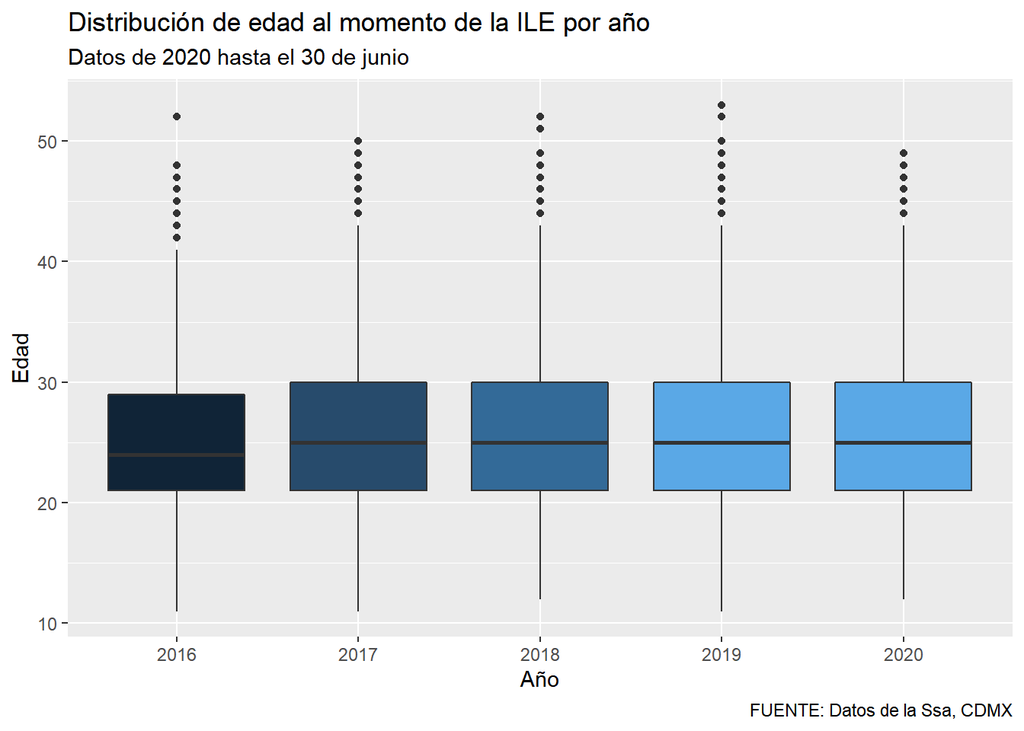

```r
# Crear base para trabajar sobre embarazos previos a aborto
(ggplot(datos
        %>% filter(año != "NA")
        %>% mutate(año = factor(año)),
        aes(x = año,
            y = edad,
            fill = año)
)
  + geom_boxplot()
  + scale_fill_manual(values = c("#102437", "#274B6C", "#336A98", "#5AA8E6", "#5AA8E6"))
  + labs(title = "Distribución de edad al momento de la ILE por año",
         subtitle = "Datos de 2020 hasta el 30 de junio",
         x = "Año",
         y = "Edad",
         caption = "FUENTE: Datos de la Ssa, CDMX")
  + theme(legend.position = "none")
)
```

Se realizó un box-plot para los datos de las edades de las personas que realizaron el procedimiento de ILE para cada uno de los años del 2016 al 2020. En el gráfico se puede ver que todos los años están distribuidos de una manera muy similar. Los cuantiles 25, 50 y 75 están localizados prácticamente en el mismo lugar para todos los años, con una pequeña excepción del año 2016, donde los cuantiles 50 y 75 están un poco por debajo que los de los demás. Es notable que todos los diagramas tienen valores extremos únicamente en el brazo superior.

- **Número de hijos por paciente**: histograma

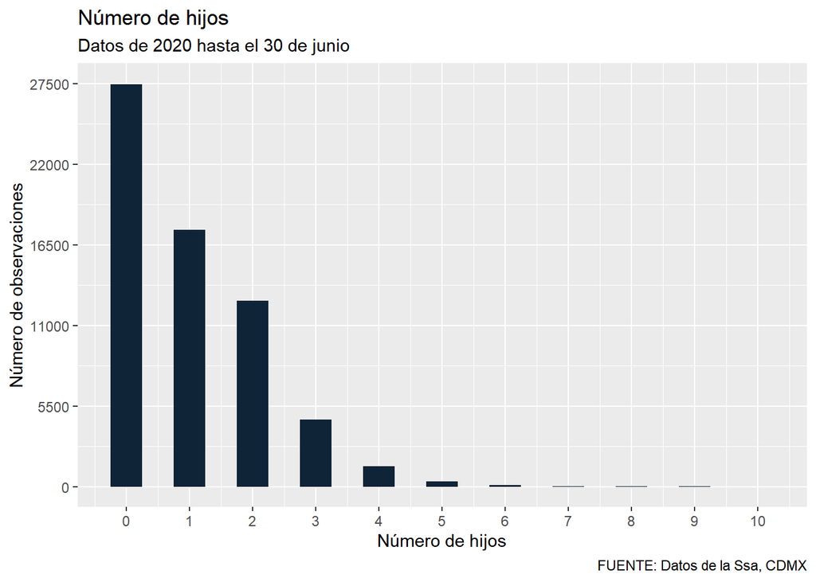

```r
# Se realiza un histograma que muestra la frecuencia absoluta de las personas que tienen n cantidad de hijos (para n=0,1,2,...,10).
  # Calcula la media y la mediana del número de hijos
datos_con_hijos <- datos %>% filter(!is.na(nhijos))
media_hijos <- mean(datos_con_hijos$nhijos)
mediana_hijos <- median(datos_con_hijos$nhijos)

(ggplot(aborto,
        aes(x = nhijos
        )
)
  + geom_histogram(binwidth = .5,
                   fill = "#102437")
  + labs(title = "Número de hijos",
         subtitle = "Datos de 2020 hasta el 30 de junio",
         x = "Número de hijos",
         y = "Número de observaciones",
         caption = "FUENTE: Datos de la Ssa, CDMX")
  + scale_x_continuous(breaks = seq(from = 0,
                                    to = 10,
                                    by = 1
  )
  )
  + scale_y_continuous(limits = c(0, 27500),
                       breaks = seq(from = 0,
                                    to = 27500,
                                    by = 5500
                       )
  )
)
```

### Análisis de salud reproductiva de la paciente

En esta parte del estudio analisamos factores como métodos anticonceptivos utilizados por las pacientes que se practican una ILE, presencia de dolor post procedimiento y algunas estadísticas.

- **Estadísticos sobre la edad de inicio de vida sexual**

```r
#Estadísticos de la edad de inicio de vida sexual
datos_vida_sexual <- datos %>% filter(!is.na(fsexual))
tabla_vida_sexual <- datos_vida_sexual %>% summarise(Media = mean(fsexual), Mediana = median(fsexual), MAD = mad(fsexual), IQR = IQR(fsexual))

#Tabla de estadísticos de la edad de inicio de la vida sexual
kable(tabla_vida_sexual, booktabs = T) %>%
  kable_styling(latex_options = "striped")
```

| Media | Mediana | MAD | IQR |
| --- | --- | --- | --- |
| 16.97562 | 17 | 1.4826 | 3 |

El 50% de nuestra población inició su vida sexual a los 17 años, coincidiendo con el promedio de la misma. Las demás personas iniciaron, en promedio, su vida sexual entre los 16 y 18 años. Finalmente,si tomamos a la población que está entre el primer cuartil y el tercer cuartil, evitando los datos muy alejados de la mediana, estas personas iniciaron su vida sexual a los 17±3 años.

- **Uso de un sólo método anticonceptivo**: gráfica de paleta

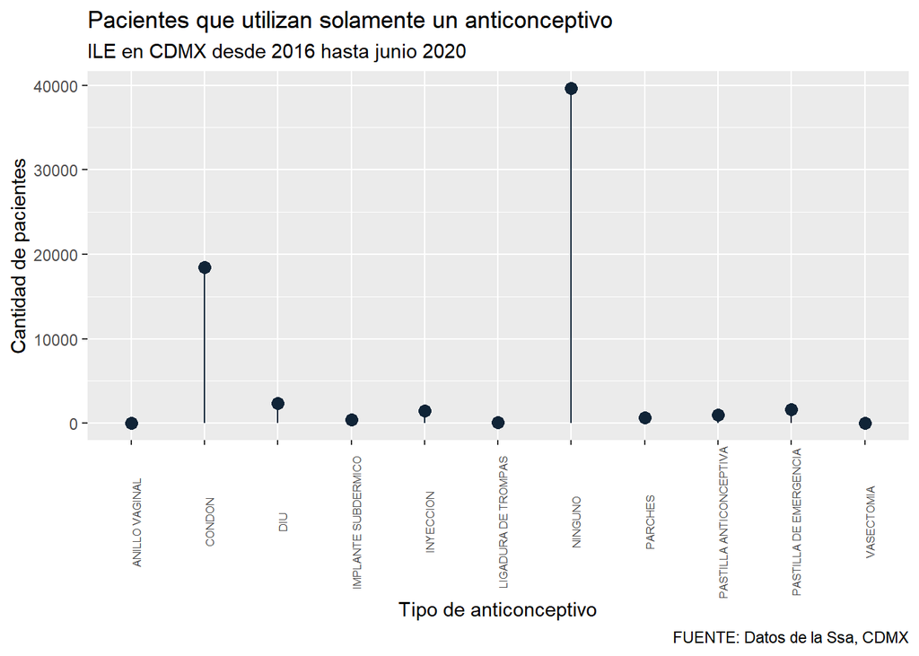

```r
#Conteo de los métodos anticonceptivos especificados
datos_anticonceptivos <- datos %>% filter(!is.na(anticonceptivo))
anticonceptivos <- datos_anticonceptivos %>% group_by(anticonceptivo) %>% tally()

#Nos quedamos con los métodos de un solo anticonceptivo
unico_antic <- anticonceptivos %>% filter(str_detect(anticonceptivo," \\+",
                                                     negate = TRUE))
#Porcentaje de quienes no usan anticonceptivo
porc_no_antic <- (unico_antic[7,2]/nrow(datos_anticonceptivos))*100
porc_no_antic <- porc_no_antic$n

#Gráfica de quienes utilizan un solo anticonceptivo
ggplot(unico_antic, aes(x = anticonceptivo, y = n)) +
  geom_point(size = 3, color = "#102437") +
  geom_segment(aes(x=anticonceptivo,
                   xend = anticonceptivo,
                   y=0,
                   yend = n), color = "#102437") +
  labs( x = "Tipo de anticonceptivo",
        y = "Cantidad de pacientes",
        title = "Pacientes que utilizan solamente un anticonceptivo",
        subtitle = "ILE en CDMX desde 2016 hasta junio 2020",
        caption = "FUENTE: Datos de la Ssa, CDMX")+
  theme(axis.text.x = element_text(angle = 90, size = 6))
```

Se realizó una tabla de las personas que utilizan uno o más anticonceptivos y un gráfico que refleja a las personas que solo utilizan un anticonceptivo regularmente. Dado que las personas que utilizan dos o más anticonceptivos son una proporción muy pequeña, se optó por no incluirlos en el gráfico. Se observa que, dentro de las personas que practican una ILE, el 53.33% no utiliza métodos anticonceptivos. Esta información debe usarse para promover el uso de métodos anticonceptivos de manera efectiva y segura.

Además, hay quienes usan más de un solo anticonceptivo; sin embargo, solo representan un pequeño porcentaje de la población, como se muestra en la siguiente tabla:

```r
# Frecuencia de los anticonceptivos
frecuencia_antic <- 100*table(datos$anticonceptivo)/nrow(datos)
kable(frecuencia_antic, booktabs = T,
      col.names = c("Anticonceptivo","Frecuencia (%)")) %>%
  kable_styling(latex_options = "hold_position")
```

| Anticonceptivo | Frecuencia (%) |
| --- | --- |
| ANILLO VAGINAL | 0.0188294 |
| CONDON | 24.8426404 |
| CONDON + DIU | 0.0134495 |
| CONDON + IMPLANTE | 0.0040349 |
| CONDON + INYECCION | 0.0067248 |
| CONDON + PARCHE | 0.0053798 |
| CONDON + PASTILLA ANTICONCEPTIVA | 0.0013450 |
| CONDON + PASTILLA DE EMERGENCIA | 0.1156660 |
| DIU | 3.2023348 |
| IMPLANTE SUBDERMICO | 0.5823650 |
| INYECCION | 1.9555627 |
| INYECCION + DIU | 0.0013450 |
| INYECCION + LIGADURA DE TROMPAS | 0.0013450 |
| LIGADURA DE TROMPAS | 0.1412201 |
| NINGUNO | 53.3395201 |
| PARCHES | 0.9333979 |
| PASTILLA ANTICONCEPTIVA | 1.3462987 |
| PASTILLA DE EMERGENCIA | 2.2043792 |
| PASTILLA DE EMERGENCIA + INYECCION | 0.0013450 |
| PASTILLA DE EMERGENCIA + PARCHES | 0.0013450 |
| VASECTOMIA | 0.0080697 |

Se puede observar que son menos las personas que procedieron a una ILE y que utilizan dos anticonceptivos habitualmente. Por ejemplo, quienes usan condón y DIU son solo un 0.013%, y quienes usan solamente condón o DIU representan un 24.84% y 3.20%, respectivamente.

- **Presencia de dolor post procedimiento**: gráfica de barras

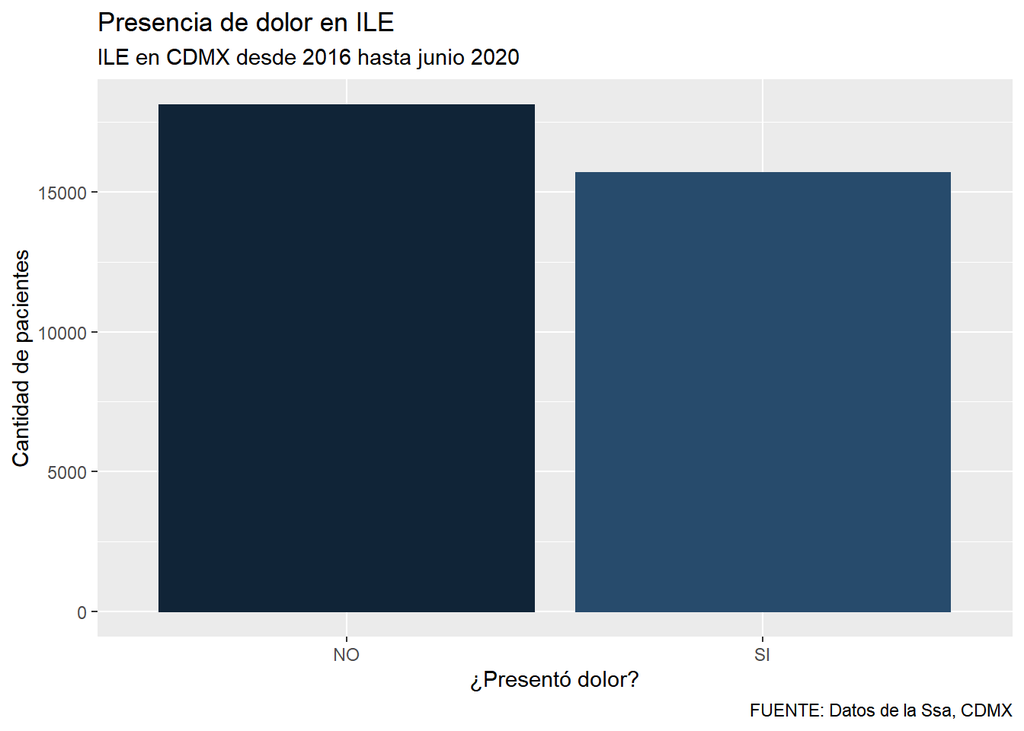

```r
# Crear base de si se presentó dolor o no
dolor <- as.data.frame(table(datos$c_dolor))
colnames(dolor) <- c("r","Cantidad")

# Gráfica de si tuvieron dolor
ggplot(dolor) +
  geom_col(aes(x = r, y = Cantidad), color = c("#102437", "#274B6C"), fill = c("#102437", "#274B6C"), show.legend = FALSE) +
  labs(
    x = "¿Presentó dolor?",
    y = "Cantidad de pacientes",
    title = "Presencia de dolor en ILE",
    subtitle = "ILE en CDMX desde 2016 hasta junio 2020",
    caption = "FUENTE: Datos de la Ssa, CDMX"
  )
```

### Análisis de procedimientos de ILE

En esta parte del estudio se busca estudiar cómo es que varía a través de los años, y los días en estos, el número de procedimientos. Para esta parte, necesitaremos realizar algunas modificaciones a la base de datos.

```r
# Agregar columnas con mes, día y año en que se realizó el procedimiento del ILE
datos <- mutate(datos, mes_proced = month(fingreso),
                día_año_proced = yday(fingreso),
                año_proced = year(fingreso))

# Eliminar entradas de año_proced con NA y 2015 (sólo 1)
datos <- datos %>% mutate(fingreso = ymd(fingreso))
datos <- filter(datos, !(year(datos$fingreso) == 2015))
```

- **Procedimientos por año**: gráficas de barras

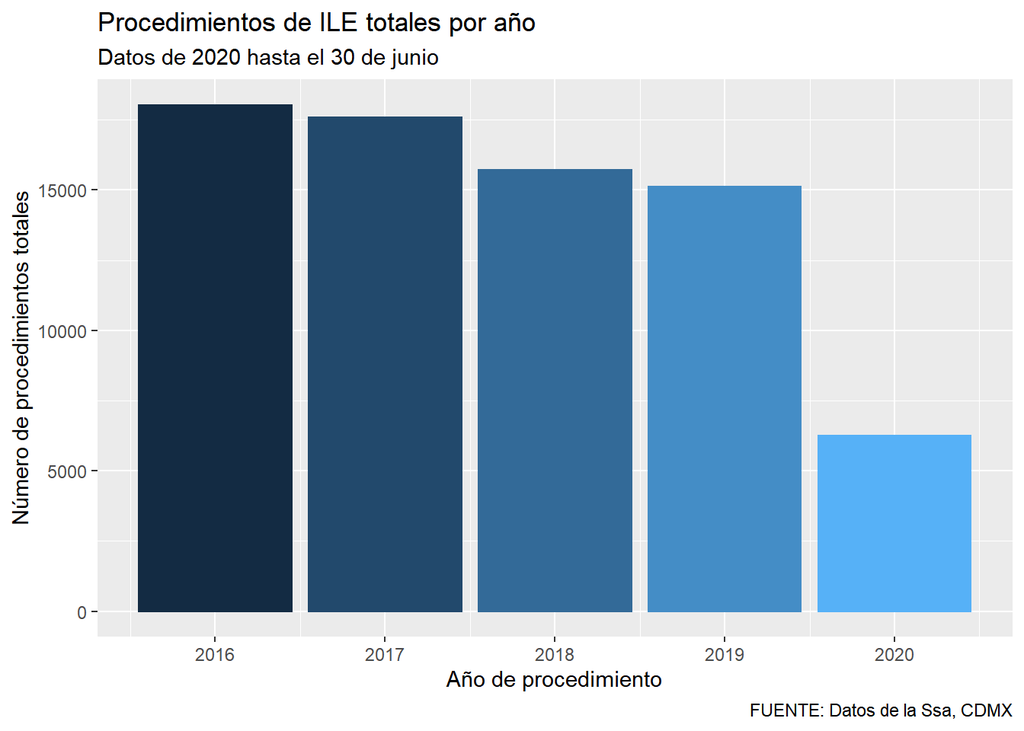

```r
# Crear base de no. de procedimientos por año TOTALES
conteo_proced_año <- tally(group_by(datos, año_proced))

# Graficar no. de procedimientos por año TOTALES
ggplot()+
  geom_col(aes(x = conteo_proced_año$año_proced, y= conteo_proced_año$n,
               color = conteo_proced_año$año_proced, fill = conteo_proced_año$año_proced), show.legend = FALSE)+
  labs(
    title = "Procedimientos de ILE totales por año",
    subtitle = "Datos de 2020 hasta el 30 de junio",
    x = "Año de procedimiento",
    y = "Número de procedimientos totales",
    caption = "FUENTE: Datos de la Ssa, CDMX"
  )
```

Aquí podemos ver que los datos de 2016 y 2017 son bastante similares, mientras que hubo una tenedencia a la baja en 2018 y 2019. La razón por la que el número de procedimientos durante el 2020 es que los datos disponibles para este año están actualizados hasta el 30 de junio. Si realizamos una modificación en el conteo para considerar los datos únicamente hasta el 30 de junio por cada año, obtenemos resultados similares, que reflejan la misma tendencia a la baja.

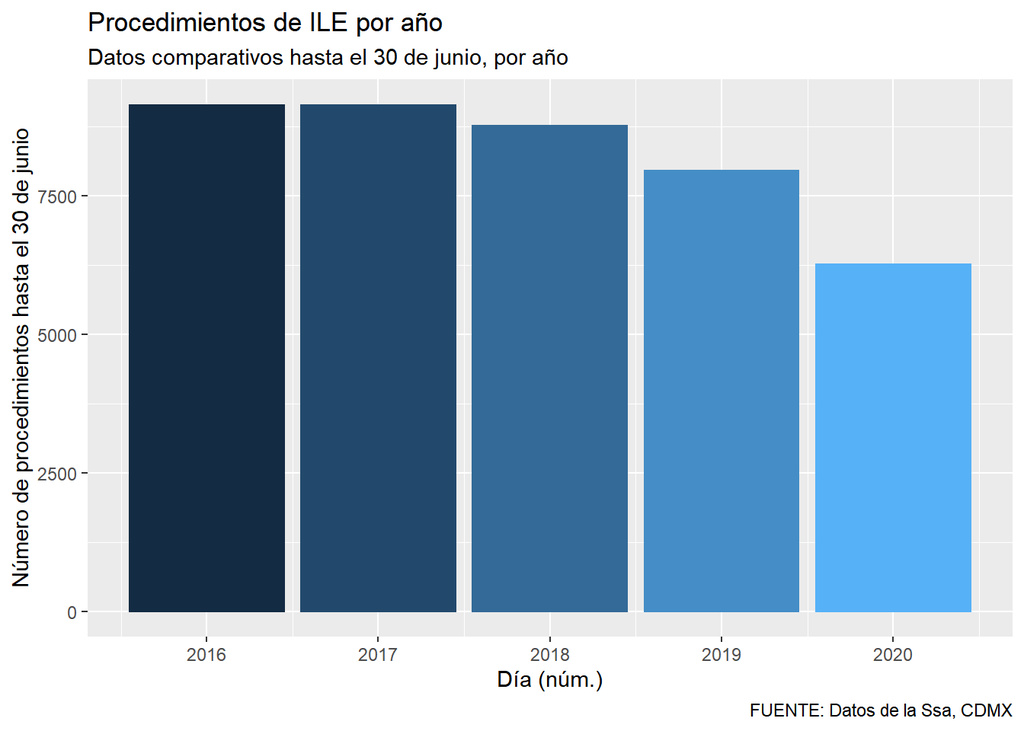

```r
# Crear base que incluya días del año hasta el día 30 de junio (último proced.
# en 2020 es en esa fecha) para cada año y poder comparar por año
datos_comp.2020 <- filter(datos, día_año_proced <= 182)

# Crear base de no. de procedimientos por año hasta 30 de junio por año
conteo_proced_compaño <-tally(group_by(datos_comp.2020, año_proced))

# Graficar no. de procedimientos por año hasta 30 de junio por año
ggplot()+
  geom_col(aes(x = conteo_proced_compaño$año_proced, y= conteo_proced_compaño$n,
               color = conteo_proced_compaño$año_proced,
               fill = conteo_proced_compaño$año_proced), show.legend = FALSE)+
  labs(
    title = "Procedimientos de ILE por año",
    subtitle = "Datos comparativos hasta el 30 de junio, por año",
    x = "Día (núm.)",
    y = "Número de procedimientos hasta el 30 de junio",
    caption = "FUENTE: Datos de la Ssa, CDMX"
  )
```

Sin embargo, es evidente una disminución mucho más drástica en el 2020 a comparación del año anterior, por lo cual realizar visualizar los datos por día, por año. Veremos que la pandemia de SARS-CoV-2 y la Jornada Nacional de Sana Distancia (JNSD) tuvieron efectos directos sobre el número de procedimientos de ILE en la CDMX.

- **Procedimientos por día, por año**: gráficas de líneas, comparativas

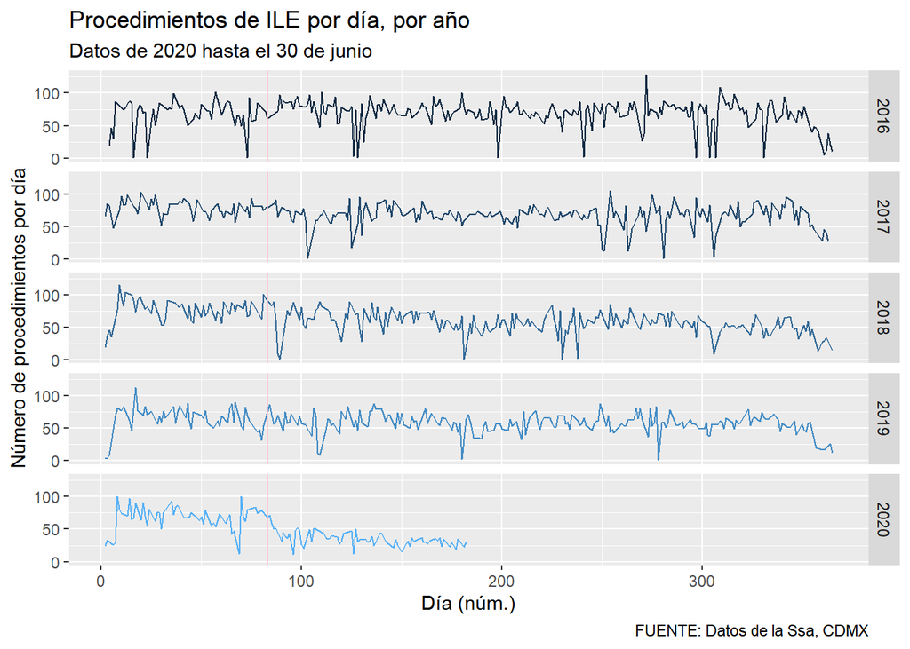

```r
# Crear base de no. de procedimientos por día de cada año, TOTALES
conteo_proced_día <- tally(group_by(datos, fingreso))

# Agregar columnas de día y año a base de no. de procedimientos por día de cada año, TOTALES
conteo_proced_día <- mutate(conteo_proced_día, día = yday(fingreso),
                        año = year(fingreso))

# Graficar no. de procedimientos por día de cada año TOTALES
ggplot(conteo_proced_día, aes(día, n)) +
  geom_line(aes(color = año), show.legend=FALSE) +
  facet_grid(año ~ .)+
  geom_vline(xintercept = 83, color = "pink")+ # Inicio de JNSD
  labs(
    title = "Procedimientos de ILE por día, por año",
    subtitle = "Datos de 2020 hasta el 30 de junio",
    x = "Día (núm.)",
    y = "Número de procedimientos por día",
    caption = "FUENTE: Datos de la Ssa, CDMX"
  )
```

Si visualizamos los datos hasta el 30 de junio por año, podremos encontrar que, de hecho, la disminución fue bastante drástica:

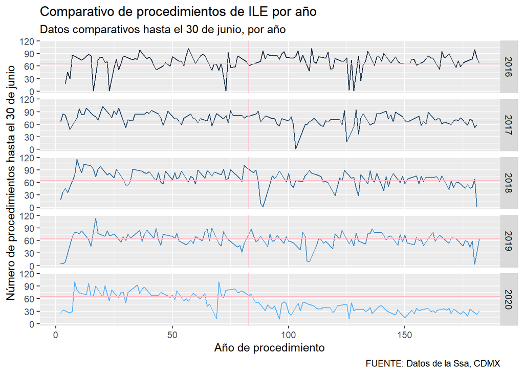

```r
# Crear base de no. de procedimientos por día hasta 30 de junio por año
conteo_proced_día_comp2020 <- tally(group_by(datos_comp.2020, fingreso))

# Modificar base de no. de procedimientos por día hasta 30 de junio por año
# para agregar columnas de día y año
conteo_proced_día_comp2020 <- mutate(conteo_proced_día_comp2020, día = yday(fingreso),
       año = year(fingreso))

#Calcular promedio de procedimientos por día hasta el 30 de junio de todos los años
prom_dia_comp2020 <- mean(conteo_proced_día_comp2020$n)

# Graficar no. de procedimientos por día hasta 30 de junio de cada año
ggplot(conteo_proced_día_comp2020, aes(día, n)) +
  geom_line(aes(color = año), show.legend = FALSE) +
  facet_grid(año ~ .)+
  geom_hline(yintercept = prom_dia_comp2020, color = "pink")+ #promedio diario
  geom_vline(xintercept = 83, color = "pink")+ # Inicio de JNSD
  labs(
    title = "Comparativo de procedimientos de ILE por año",
    subtitle = "Datos comparativos hasta el 30 de junio, por año",
    x = "Año de procedimiento",
    y = "Número de procedimientos hasta el 30 de junio",
    caption = "FUENTE: Datos de la Ssa, CDMX"
  )
```

- **Procedimientos por semana de gestación**: gráfica de columnas.

Ahora queremos analizar el número de procedimientos por semana de gestación durante la cuál se realizan.

Para ello, creamos una base que nos permita realizar la comparación y graficaremos el número de procedimientos por semana de gestación en que se realizaron.

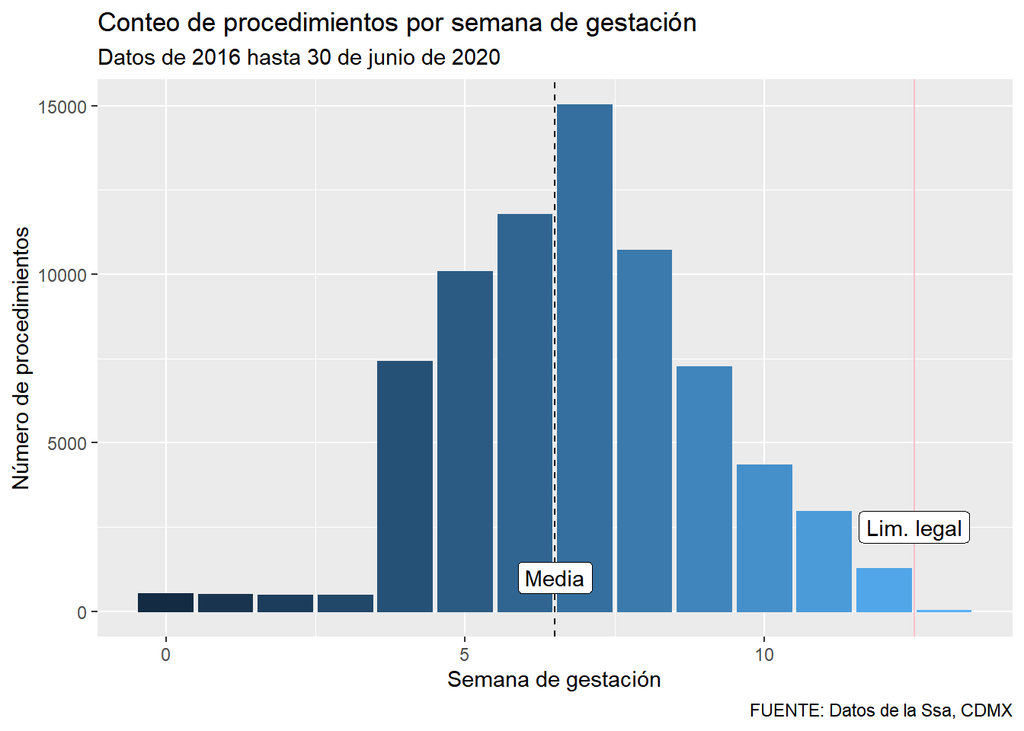

```r
# Creamos base que nos permita realizar el estudio por semana de geestación
datos_comp_sgd <- filter(datos, !(is.na(p_semgest)))
conteo_semgest <- tally(group_by(datos_comp_sgd, p_semgest))

# Graficar no. de procedimientos por p_semgest
ggplot(conteo_semgest, aes(x = p_semgest))+
  geom_col(aes(y = n, color = p_semgest, fill = p_semgest), show.legend = FALSE)+
  geom_vline(xintercept = 12.5, color = "pink")+ # Límite de 12 semanas, legal
  geom_vline(xintercept = mean(conteo_semgest$p_semgest),
             linetype = "dashed", color = "black")+ # media
  geom_label(aes(x = mean(conteo_semgest$p_semgest), y = 1000),
             label = "Media")+
  geom_label(aes(x = 12.5, y = 2500),
             label = "Lim. legal")+
  labs(
    title = "Conteo de procedimientos por semana de gestación",
    subtitle = "Datos de 2016 hasta 30 de junio de 2020",
    x = "Semana de gestación",
    y = "Número de procedimientos",
    caption = "FUENTE: Datos de la Ssa, CDMX"
  )
```

## CONLCUSIÓN

Los datos son muy claros, y la única modificación esencial en el comportameinto se debió a la pandemia de SARS-CoV-2 y sus implicaciones prácticas en México: la JNSD, el confinamiento y el miedo a contagiarse. Sin embargo, y a pesar de la notable tendencia a la baja a través de los años, la ILE sigue siendo una práctica esencial para el pleno desarrollo de la vida humana de las mujeres hembras en México.

El derecho al aborto ha hecho las oportunidades vitales más accesibles para jóvenes mexicanas, y continuará siéndolo por siempre, pues el derecho a decidir es un derecho humano.